# Money Ball - Data 621 Project 1

Jack Russo, Javern Wilson, Joseph Simone, Anthony Munoz, Paul Perez

03-01-2020

**Overview**

In this homework assignment, we will explore, analyze and model a data set containing approximately 2200 records. This analysis attempts to predict the number of wins for the teams. Each record represents a professional baseball team from the years 1871 to 2006 inclusive. Each record has the performance of the team for the given year, with all of the statistics adjusted to match the performance of a 162 game season.

## Part i. DATA EXPLORATION

### Preview

Below is a preview of what the dataset contains.

|  | INDEX | TARGET_WINS | TEAM_BATTING_H | TEAM_BATTING_2B | TEAM_BATTING_3B | TEAM_BATTING_HR | TEAM_BATTING_BB | TEAM_BATTING_SO | TEAM_BASERUN_SB | TEAM_BASERUN_CS | TEAM_BATTING_HBP | TEAM_PITCHING_H | TEAM_PITCHING_HR | TEAM_PITCHING_BB | TEAM_PITCHING_SO | TEAM_FIELDING_E | TEAM_FIELDING_DP |
| --- | --- | --- | --- | --- | --- | --- | --- | --- | --- | --- | --- | --- | --- | --- | --- | --- | --- |
| 1 | 1 | 39 | 1445 | 194 | 39 | 13 | 143 | 842 | NA | NA | NA | 9364 | 84 | 927 | 5456 | 1011 | NA |
| 2 | 2 | 70 | 1339 | 219 | 22 | 190 | 685 | 1075 | 37 | 28 | NA | 1347 | 191 | 689 | 1082 | 193 | 155 |
| 3 | 3 | 86 | 1377 | 232 | 35 | 137 | 602 | 917 | 46 | 27 | NA | 1377 | 137 | 602 | 917 | 175 | 153 |
| 4 | 4 | 70 | 1387 | 209 | 38 | 96 | 451 | 922 | 43 | 30 | NA | 1396 | 97 | 454 | 928 | 164 | 156 |
| 5 | 5 | 82 | 1297 | 186 | 27 | 102 | 472 | 920 | 49 | 39 | NA | 1297 | 102 | 472 | 920 | 138 | 168 |
| 6 | 6 | 75 | 1279 | 200 | 36 | 92 | 443 | 973 | 107 | 59 | NA | 1279 | 92 | 443 | 973 | 123 | 149 |
| 7 | 7 | 80 | 1244 | 179 | 54 | 122 | 525 | 1062 | 80 | 54 | NA | 1244 | 122 | 525 | 1062 | 136 | 186 |
| 8 | 8 | 85 | 1273 | 171 | 37 | 115 | 456 | 1027 | 40 | 36 | NA | 1281 | 116 | 459 | 1033 | 112 | 136 |
| 9 | 11 | 86 | 1391 | 197 | 40 | 114 | 447 | 922 | 69 | 27 | NA | 1391 | 114 | 447 | 922 | 127 | 169 |
| 10 | 12 | 76 | 1271 | 213 | 18 | 96 | 441 | 827 | 72 | 34 | NA | 1271 | 96 | 441 | 827 | 131 | 159 |

### Structure of Data

```
## 'data.frame':    2276 obs. of  17 variables:
##  $ INDEX           : int  1 2 3 4 5 6 7 8 11 12 ...
##  $ TARGET_WINS     : int  39 70 86 70 82 75 80 85 86 76 ...
##  $ TEAM_BATTING_H  : int  1445 1339 1377 1387 1297 1279 1244 1273 1391 1271 ...
##  $ TEAM_BATTING_2B : int  194 219 232 209 186 200 179 171 197 213 ...
##  $ TEAM_BATTING_3B : int  39 22 35 38 27 36 54 37 40 18 ...
##  $ TEAM_BATTING_HR : int  13 190 137 96 102 92 122 115 114 96 ...
##  $ TEAM_BATTING_BB : int  143 685 602 451 472 443 525 456 447 441 ...
##  $ TEAM_BATTING_SO : int  842 1075 917 922 920 973 1062 1027 922 827 ...
##  $ TEAM_BASERUN_SB : int  NA 37 46 43 49 107 80 40 69 72 ...
##  $ TEAM_BASERUN_CS : int  NA 28 27 30 39 59 54 36 27 34 ...
##  $ TEAM_BATTING_HBP: int  NA NA NA NA NA NA NA NA NA NA ...
##  $ TEAM_PITCHING_H : int  9364 1347 1377 1396 1297 1279 1244 1281 1391 1271 ...
##  $ TEAM_PITCHING_HR: int  84 191 137 97 102 92 122 116 114 96 ...
##  $ TEAM_PITCHING_BB: int  927 689 602 454 472 443 525 459 447 441 ...
##  $ TEAM_PITCHING_SO: int  5456 1082 917 928 920 973 1062 1033 922 827 ...
##  $ TEAM_FIELDING_E : int  1011 193 175 164 138 123 136 112 127 131 ...
##  $ TEAM_FIELDING_DP: int  NA 155 153 156 168 149 186 136 169 159 ...
```

At first glance, we can see that `TEAM_BATTING_HBP` has a lot of missing data. Let’s look at the summary to see if it reveals further information on the data.

### Summary of Data

```
##      INDEX         TARGET_WINS     TEAM_BATTING_H TEAM_BATTING_2B
##  Min.   :   1.0   Min.   :  0.00   Min.   : 891   Min.   : 69.0
##  1st Qu.: 630.8   1st Qu.: 71.00   1st Qu.:1383   1st Qu.:208.0
##  Median :1270.5   Median : 82.00   Median :1454   Median :238.0
##  Mean   :1268.5   Mean   : 80.79   Mean   :1469   Mean   :241.2
##  3rd Qu.:1915.5   3rd Qu.: 92.00   3rd Qu.:1537   3rd Qu.:273.0
##  Max.   :2535.0   Max.   :146.00   Max.   :2554   Max.   :458.0
##
##  TEAM_BATTING_3B  TEAM_BATTING_HR  TEAM_BATTING_BB TEAM_BATTING_SO
##  Min.   :  0.00   Min.   :  0.00   Min.   :  0.0   Min.   :   0.0
##  1st Qu.: 34.00   1st Qu.: 42.00   1st Qu.:451.0   1st Qu.: 548.0
##  Median : 47.00   Median :102.00   Median :512.0   Median : 750.0
##  Mean   : 55.25   Mean   : 99.61   Mean   :501.6   Mean   : 735.6
##  3rd Qu.: 72.00   3rd Qu.:147.00   3rd Qu.:580.0   3rd Qu.: 930.0
##  Max.   :223.00   Max.   :264.00   Max.   :878.0   Max.   :1399.0
##                                                    NA's   :102
##  TEAM_BASERUN_SB TEAM_BASERUN_CS TEAM_BATTING_HBP TEAM_PITCHING_H
##  Min.   :  0.0   Min.   :  0.0   Min.   :29.00    Min.   : 1137
##  1st Qu.: 66.0   1st Qu.: 38.0   1st Qu.:50.50    1st Qu.: 1419
##  Median :101.0   Median : 49.0   Median :58.00    Median : 1518
##  Mean   :124.8   Mean   : 52.8   Mean   :59.36    Mean   : 1779
##  3rd Qu.:156.0   3rd Qu.: 62.0   3rd Qu.:67.00    3rd Qu.: 1682
##  Max.   :697.0   Max.   :201.0   Max.   :95.00    Max.   :30132
##  NA's   :131     NA's   :772     NA's   :2085
##  TEAM_PITCHING_HR TEAM_PITCHING_BB TEAM_PITCHING_SO  TEAM_FIELDING_E
##  Min.   :  0.0    Min.   :   0.0   Min.   :    0.0   Min.   :  65.0
##  1st Qu.: 50.0    1st Qu.: 476.0   1st Qu.:  615.0   1st Qu.: 127.0
##  Median :107.0    Median : 536.5   Median :  813.5   Median : 159.0
##  Mean   :105.7    Mean   : 553.0   Mean   :  817.7   Mean   : 246.5
##  3rd Qu.:150.0    3rd Qu.: 611.0   3rd Qu.:  968.0   3rd Qu.: 249.2
##  Max.   :343.0    Max.   :3645.0   Max.   :19278.0   Max.   :1898.0
##                                    NA's   :102
##  TEAM_FIELDING_DP
##  Min.   : 52.0
##  1st Qu.:131.0
##  Median :149.0
##  Mean   :146.4
##  3rd Qu.:164.0
##  Max.   :228.0
##  NA's   :286
```

Based on the summary above we have our work cut out for us, especially when handling missing values. There are 6 variables with missing values:

- **TEAM_BATTING_SO**: `102`
- **TEAM_BASERUN_SB**: `131`
- **TEAM_BASERUN_CS**: `772`
- **TEAM_BATTING_HBP**: `2085`
- **TEAM_PITCHING_SO**: `102`
- **TEAM_FIELDING_DP**: `286`

Some variables also have a minumum of 0. Whether or not there values affect our model outcome will be interesting to find out as we move forward.

```
## [1] 8.39
```

About only `8%` of the data has complete rows.

On this next plot is a graphic representation of what variable has missing values. As mentioned earlier, the six variables that have missing values can be visually observed here. One of our goal when completing the project is knowing how to handle missing values effectively in order to reduce bias and produce useful and powerful models.

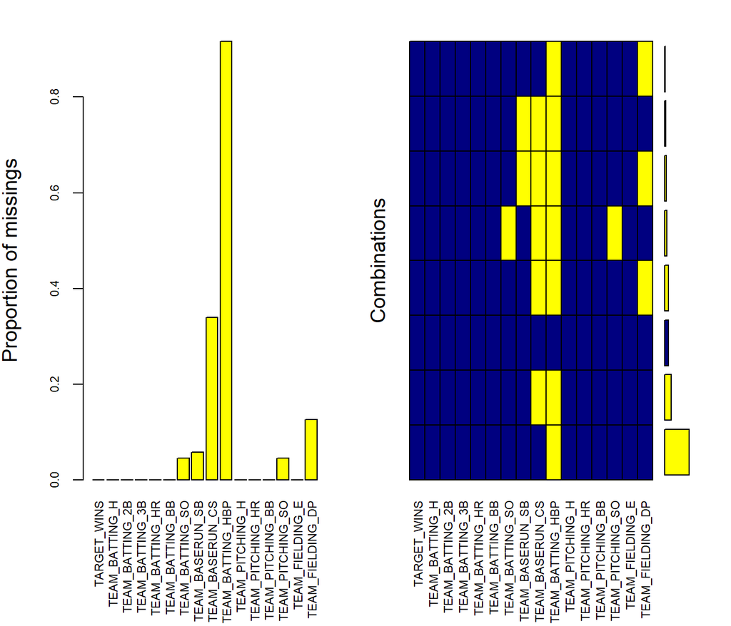

### Further Descriptive Analytics

Here we look at more descriptive analytics on the raw dataset.

|  | vars | n | mean | sd | median | trimmed | mad | min | max | range | skew | kurtosis | se |
| --- | --- | --- | --- | --- | --- | --- | --- | --- | --- | --- | --- | --- | --- |
| TARGET_WINS | 1 | 2276 | 80.79086 | 15.75215 | 82.0 | 81.31229 | 14.8260 | 0 | 146 | 146 | -0.3987232 | 1.027475675 | 0.3301823 |
| TEAM_BATTING_H | 2 | 2276 | 1469.26977 | 144.59120 | 1454.0 | 1459.04116 | 114.1602 | 891 | 2554 | 1663 | 1.5713335 | 7.278526076 | 3.0307891 |
| TEAM_BATTING_2B | 3 | 2276 | 241.24692 | 46.80141 | 238.0 | 240.39627 | 47.4432 | 69 | 458 | 389 | 0.2151018 | 0.006160915 | 0.9810087 |
| TEAM_BATTING_3B | 4 | 2276 | 55.25000 | 27.93856 | 47.0 | 52.17563 | 23.7216 | 0 | 223 | 223 | 1.1094652 | 1.503241779 | 0.5856226 |
| TEAM_BATTING_HR | 5 | 2276 | 99.61204 | 60.54687 | 102.0 | 97.38529 | 78.5778 | 0 | 264 | 264 | 0.1860421 | -0.963118866 | 1.2691285 |
| TEAM_BATTING_BB | 6 | 2276 | 501.55888 | 122.67086 | 512.0 | 512.18332 | 94.8864 | 0 | 878 | 878 | -1.0257599 | 2.182854353 | 2.5713150 |
| TEAM_BATTING_SO | 7 | 2174 | 735.60534 | 248.52642 | 750.0 | 742.31322 | 284.6592 | 0 | 1399 | 1399 | -0.2978001 | -0.320799208 | 5.3301912 |
| TEAM_BASERUN_SB | 8 | 2145 | 124.76177 | 87.79117 | 101.0 | 110.81188 | 60.7866 | 0 | 697 | 697 | 1.9724140 | 5.489675441 | 1.8955584 |
| TEAM_BASERUN_CS | 9 | 1504 | 52.80386 | 22.95634 | 49.0 | 50.35963 | 17.7912 | 0 | 201 | 201 | 1.9762180 | 7.620381803 | 0.5919414 |
| TEAM_BATTING_HBP | 10 | 191 | 59.35602 | 12.96712 | 58.0 | 58.86275 | 11.8608 | 29 | 95 | 66 | 0.3185754 | -0.111982844 | 0.9382681 |

[output cut: 6 more lines]

### Boxplot: Exploring Outliers

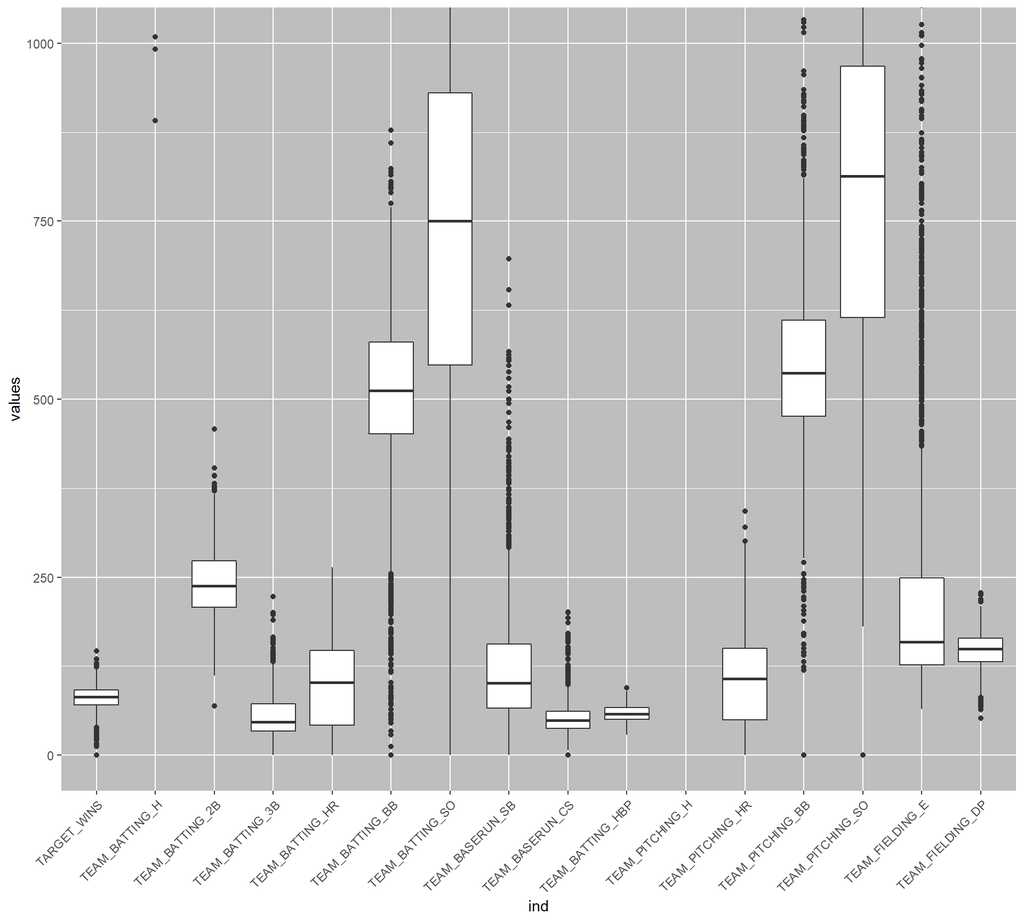

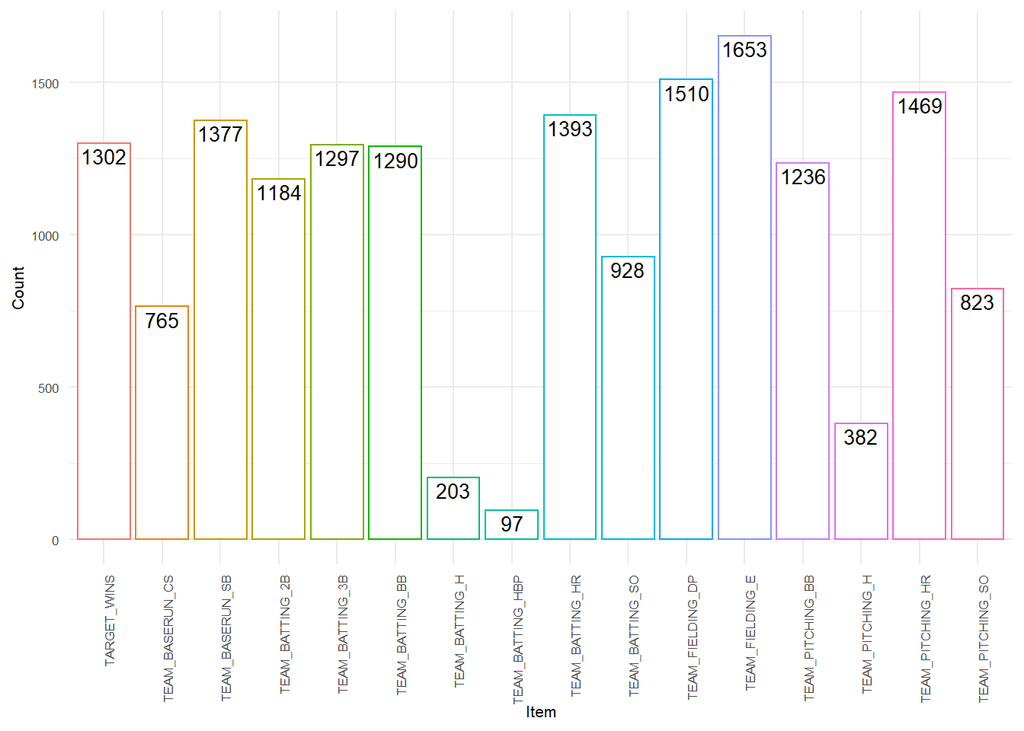

Results show that TEAM_FIELDING_E has the most outliers amongst the predictors and target variable.

### Skewness in Data

Histogram graphic displaying the distribution for each variables.

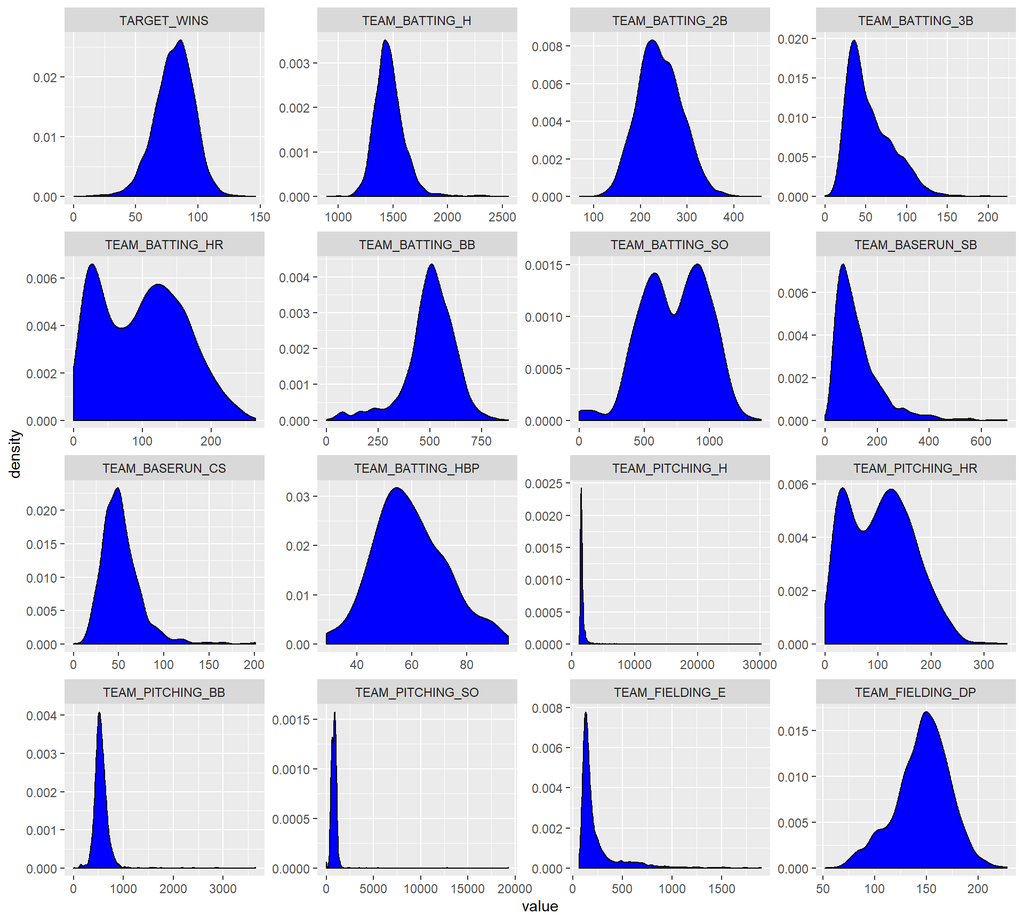

### Correlations

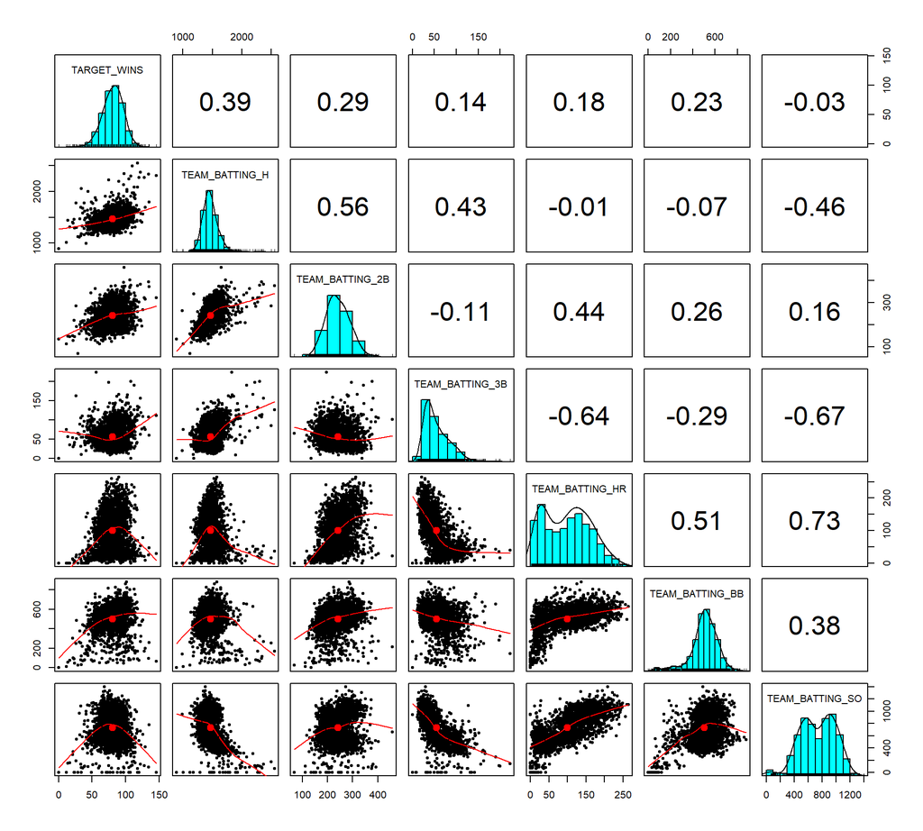

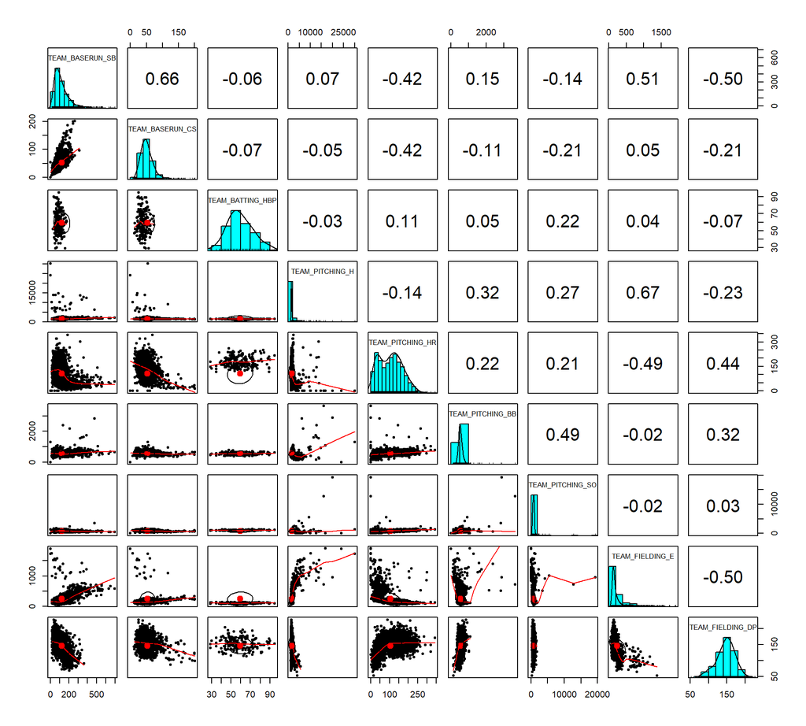

Closer look at correlations with dependant variable.

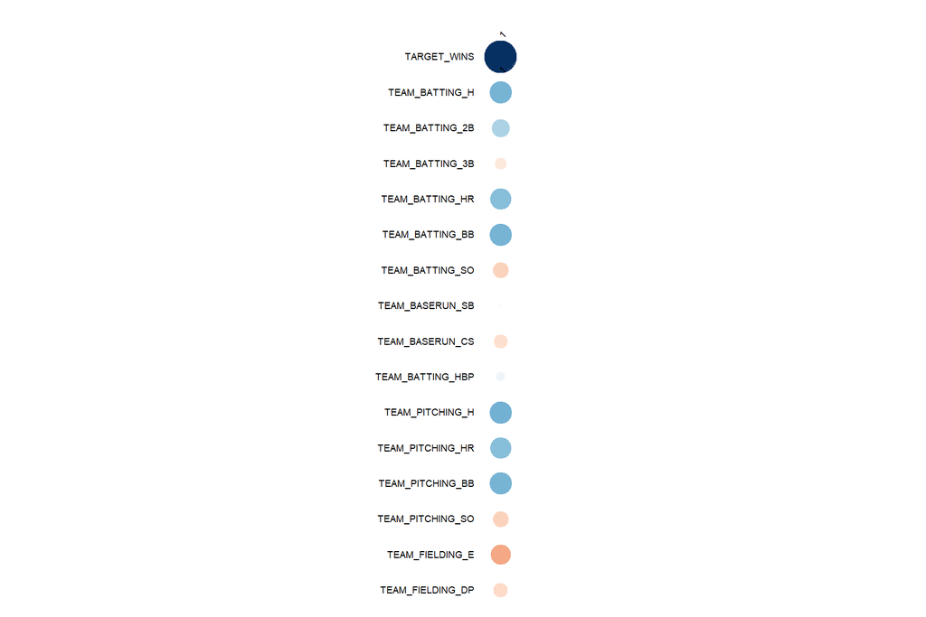

From this Corrplot, we can see the variables `Team_Batting_H,Team_Batting_2B,Team_Batting_HR, Team_Batting_BB, Team_Pitching_H,Team_Pitching_HR, and Team_Pitching_BB`, all are positively correlated with Target_Wins. Not all variables we’d expect to have a positive contribution do so. For example the number of three base hits is negatively correlated with total wins. Why two base hits contributes positively and three base hits does the opposite is unclear. Walks allowed is also strangely positively correlated with wins.

## Part ii. DATA PREPARATION

We will prepare our data using two formats: Filtering using booleans and missing value imputation. The outcome of how the models perform will based on the results provided by these two methods.

**Objective 1**: Ensure each variable can independently explain the variance in total wins. Ideally the residuals are smoothly and independently distributed around 0. Our aim should be to construct a vector of booleans that filters the noise from our explanatory variables.

**Objective 2**: Missing values can be a problem when trying to do analysis on the data. In most models, missing values are excluded which can limit the amount of information available in the analysis. This is the case why we have to either remove the missing values, impute them or model them. In this example, missing values will be imputed.

### Filtering Noise

#### Doubles vs Residuals

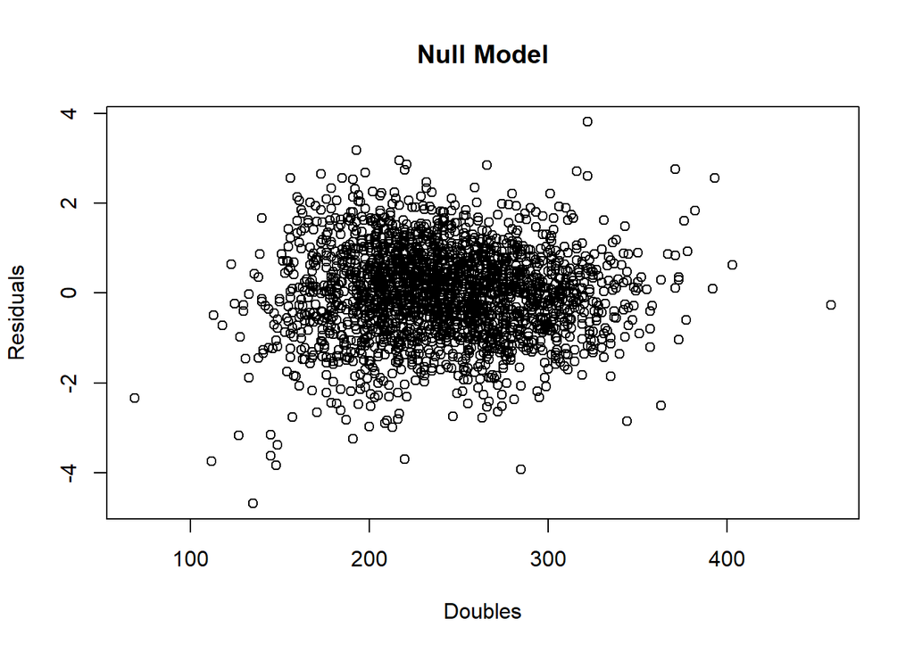

For a range from 150 to 350 doubles, the explanatory variable doubles apears to satisfy our assumptions (independence, homoscedasity) well. Most of our doubles data points are confined to this range. Therefore our transformation will consist of constraining the range of our explanatory variable.

#### Doubles Range (150 -350) vs Residuals

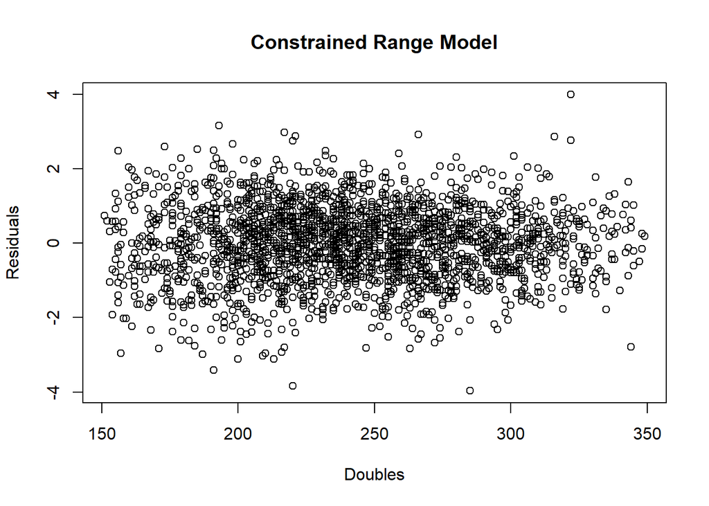

This worked very well. We can now create modified doubles and wins variables with only this range to use in our final model.

#### Home Runs vs Residuals

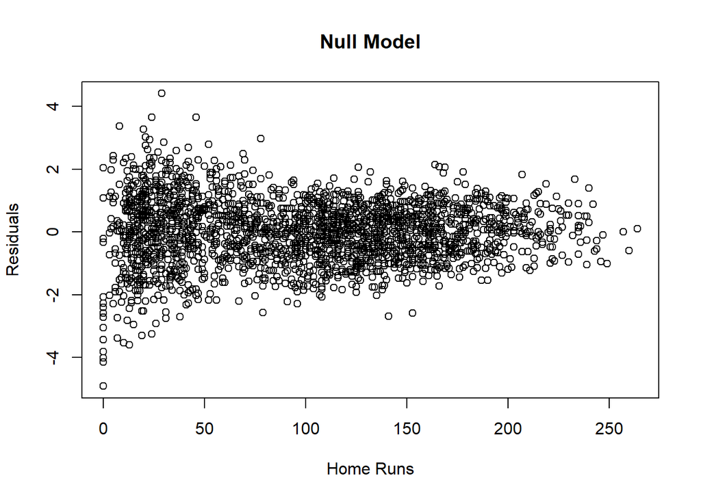

The explainitory variable Home Runs appears to satisfy our assumptions (independence, homoscedasity) well.There does appear to be some curvature for the home run range less than 50. We can take the square root of the explanatory variable to flatten this fish tail in the data

#### Home Runs vs Residuals

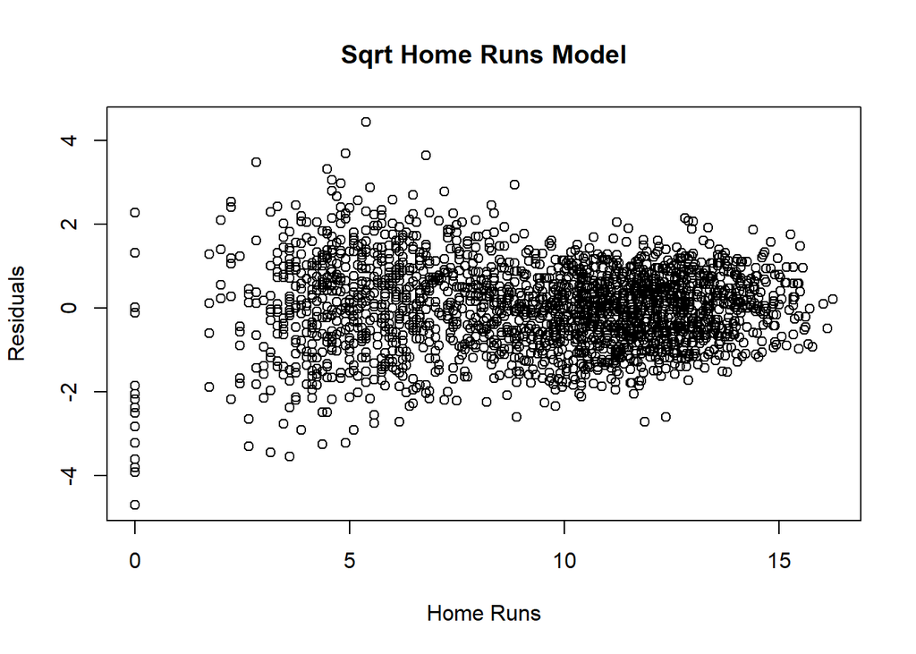

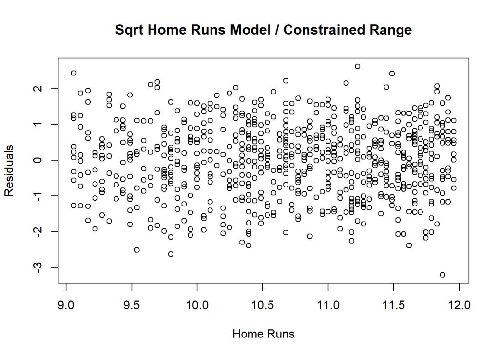

As can be seen from the range of residuals, the preceeding transformations have provided an explanatory variable that satisfies our assumptions. We can now further filter our data with a new explanatory variable and filtered target variable.

#### Walks vs Residuals

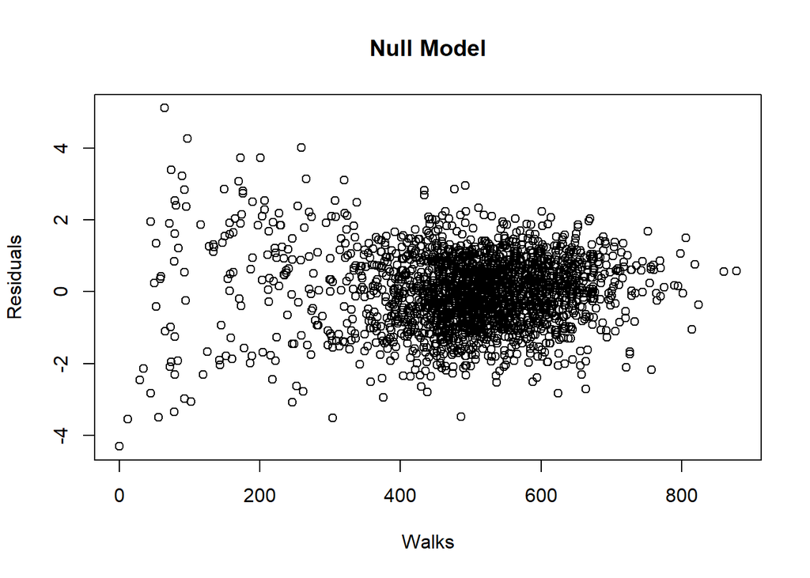

For walks we can see a situation similar to doubles. Let’s zoom into the range between 400 and 700

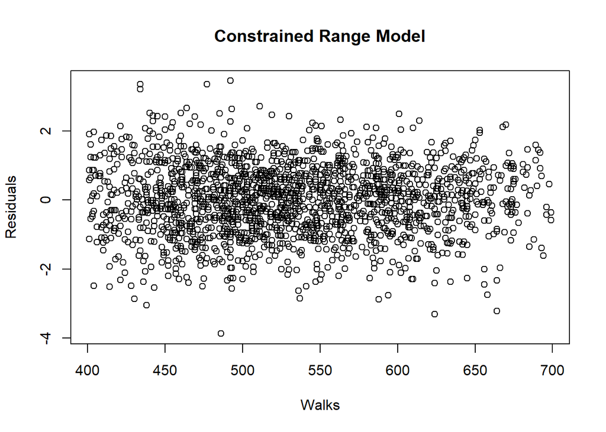

Much better! Let’s store the boolean vector for walks.

#### Strikeouts

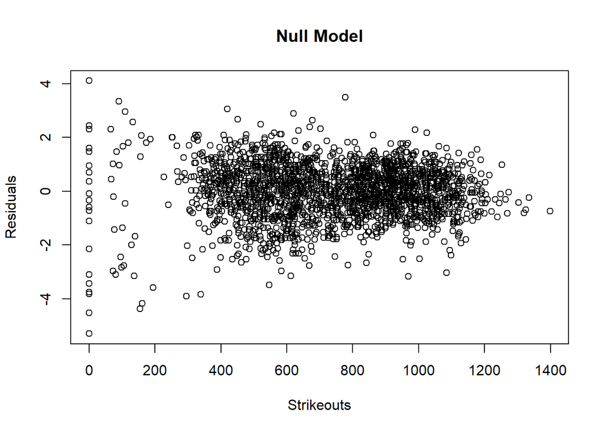

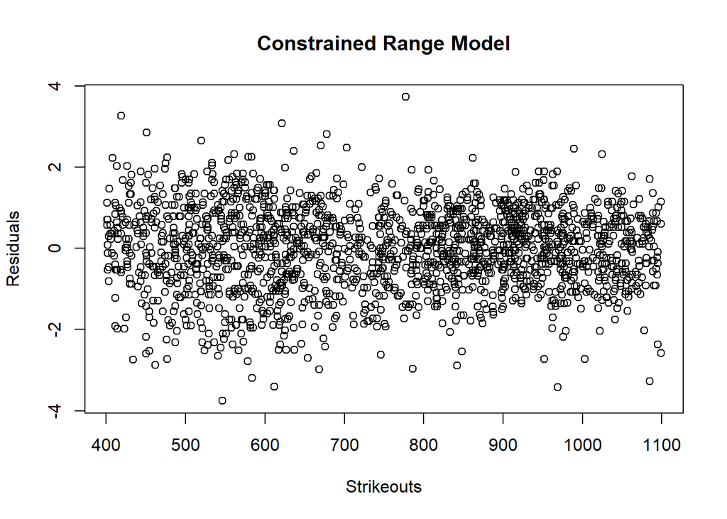

#### Fielding Errors

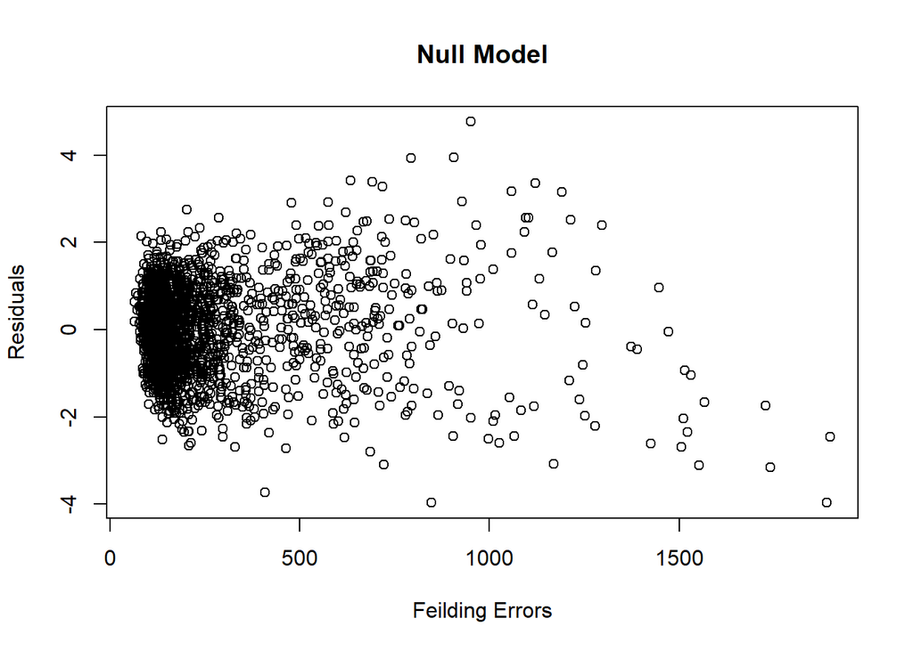

#### Feilding Errors vs Residuals

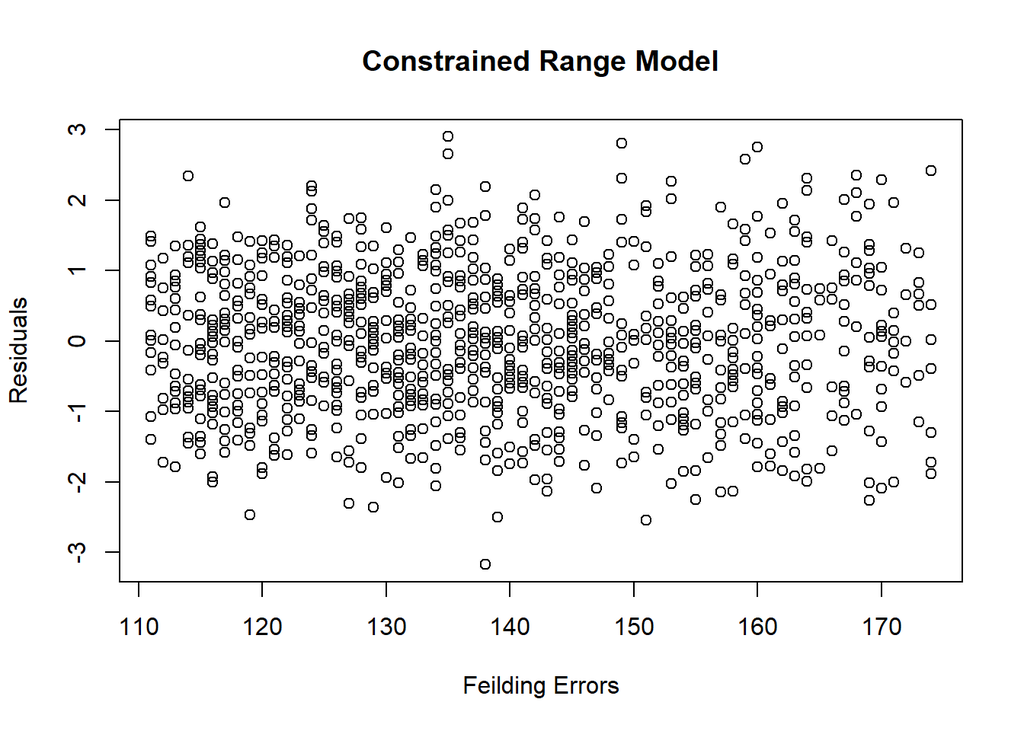

Combine Vectors and Filter Training Dataset.

### Impute Missing data

#### Preview

Look especially at the the variable TEAM_BATTING_HBP compared to original data it has 90% of its values missing.

|  | TARGET_WINS | TEAM_BATTING_H | TEAM_BATTING_2B | TEAM_BATTING_3B | TEAM_BATTING_HR | TEAM_BATTING_BB | TEAM_BATTING_SO | TEAM_BASERUN_SB | TEAM_BASERUN_CS | TEAM_BATTING_HBP | TEAM_PITCHING_H | TEAM_PITCHING_HR | TEAM_PITCHING_BB | TEAM_PITCHING_SO | TEAM_FIELDING_E | TEAM_FIELDING_DP |
| --- | --- | --- | --- | --- | --- | --- | --- | --- | --- | --- | --- | --- | --- | --- | --- | --- |
| 1 | 39 | 1445 | 194 | 39 | 13 | 143 | 842 | 231 | 193 | 72 | 9364 | 84 | 927 | 5456 | 1011 | 219 |
| 2 | 70 | 1339 | 219 | 22 | 190 | 685 | 1075 | 37 | 28 | 44 | 1347 | 191 | 689 | 1082 | 193 | 155 |
| 3 | 86 | 1377 | 232 | 35 | 137 | 602 | 917 | 46 | 27 | 45 | 1377 | 137 | 602 | 917 | 175 | 153 |
| 4 | 70 | 1387 | 209 | 38 | 96 | 451 | 922 | 43 | 30 | 48 | 1396 | 97 | 454 | 928 | 164 | 156 |
| 5 | 82 | 1297 | 186 | 27 | 102 | 472 | 920 | 49 | 39 | 58 | 1297 | 102 | 472 | 920 | 138 | 168 |
| 6 | 75 | 1279 | 200 | 36 | 92 | 443 | 973 | 107 | 59 | 39 | 1279 | 92 | 443 | 973 | 123 | 149 |
| 7 | 80 | 1244 | 179 | 54 | 122 | 525 | 1062 | 80 | 54 | 56 | 1244 | 122 | 525 | 1062 | 136 | 186 |
| 8 | 85 | 1273 | 171 | 37 | 115 | 456 | 1027 | 40 | 36 | 68 | 1281 | 116 | 459 | 1033 | 112 | 136 |
| 9 | 86 | 1391 | 197 | 40 | 114 | 447 | 922 | 69 | 27 | 80 | 1391 | 114 | 447 | 922 | 127 | 169 |
| 10 | 76 | 1271 | 213 | 18 | 96 | 441 | 827 | 72 | 34 | 48 | 1271 | 96 | 441 | 827 | 131 | 159 |

Visual of complete dataset

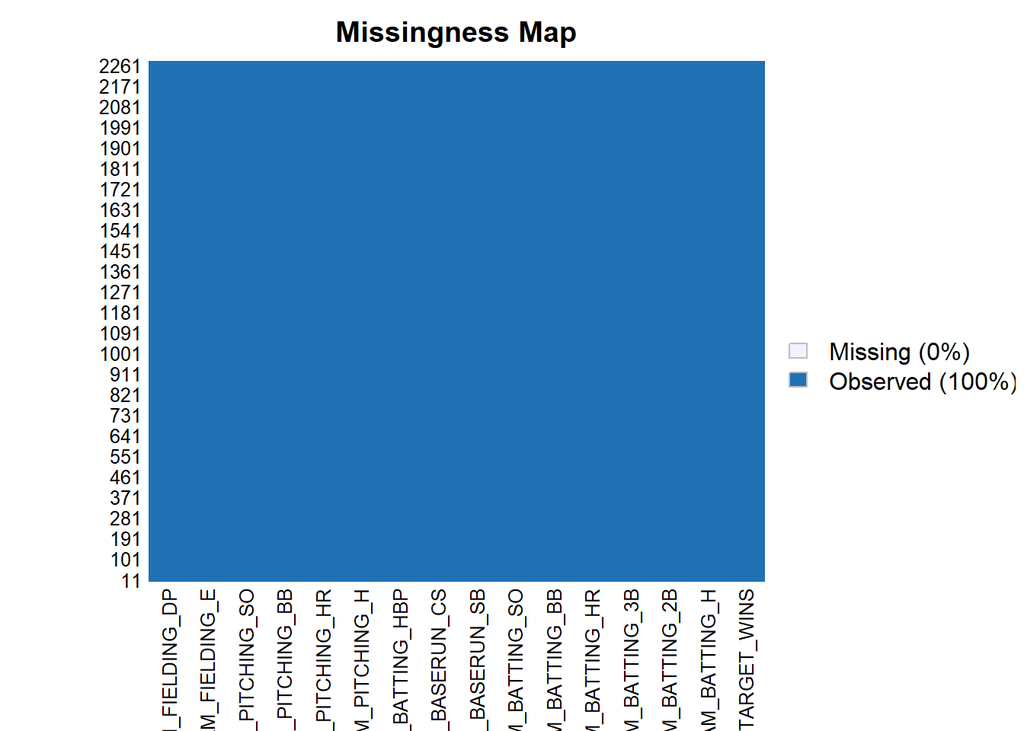

The dataset now consist of only complete rows where each missing value is replaced via the predictive mean method.

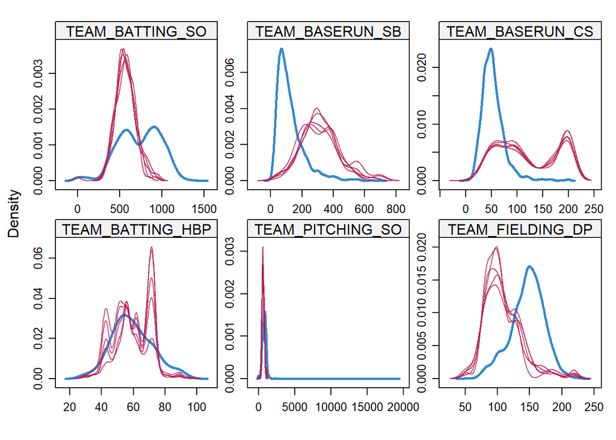

The Stripplot shows where the missing values were imputed based on the variables.

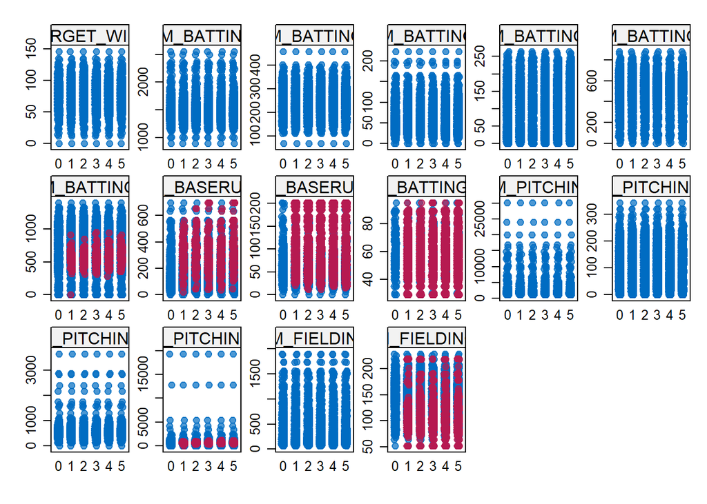

After imputation we can see that every variable has a value in each row and the NAs are gone.

```
##   TARGET_WINS     TEAM_BATTING_H TEAM_BATTING_2B TEAM_BATTING_3B
##  Min.   :  0.00   Min.   : 891   Min.   : 69.0   Min.   :  0.00
##  1st Qu.: 71.00   1st Qu.:1383   1st Qu.:208.0   1st Qu.: 34.00
##  Median : 82.00   Median :1454   Median :238.0   Median : 47.00
##  Mean   : 80.79   Mean   :1469   Mean   :241.2   Mean   : 55.25
##  3rd Qu.: 92.00   3rd Qu.:1537   3rd Qu.:273.0   3rd Qu.: 72.00
##  Max.   :146.00   Max.   :2554   Max.   :458.0   Max.   :223.00
##  TEAM_BATTING_HR  TEAM_BATTING_BB TEAM_BATTING_SO  TEAM_BASERUN_SB
##  Min.   :  0.00   Min.   :  0.0   Min.   :   0.0   Min.   :  0.0
##  1st Qu.: 42.00   1st Qu.:451.0   1st Qu.: 542.0   1st Qu.: 67.0
##  Median :102.00   Median :512.0   Median : 734.5   Median :105.5
##  Mean   : 99.61   Mean   :501.6   Mean   : 728.0   Mean   :135.2
##  3rd Qu.:147.00   3rd Qu.:580.0   3rd Qu.: 925.0   3rd Qu.:170.0
##  Max.   :264.00   Max.   :878.0   Max.   :1399.0   Max.   :697.0
##  TEAM_BASERUN_CS  TEAM_BATTING_HBP TEAM_PITCHING_H TEAM_PITCHING_HR
##  Min.   :  0.00   Min.   :29.00    Min.   : 1137   Min.   :  0.0
##  1st Qu.: 43.00   1st Qu.:51.00    1st Qu.: 1419   1st Qu.: 50.0
##  Median : 57.00   Median :61.00    Median : 1518   Median :107.0
##  Mean   : 75.05   Mean   :60.00    Mean   : 1779   Mean   :105.7
##  3rd Qu.: 90.00   3rd Qu.:70.25    3rd Qu.: 1682   3rd Qu.:150.0
##  Max.   :201.00   Max.   :95.00    Max.   :30132   Max.   :343.0
##  TEAM_PITCHING_BB TEAM_PITCHING_SO  TEAM_FIELDING_E  TEAM_FIELDING_DP
##  Min.   :   0.0   Min.   :    0.0   Min.   :  65.0   Min.   : 52.0
##  1st Qu.: 476.0   1st Qu.:  607.8   1st Qu.: 127.0   1st Qu.:124.0
##  Median : 536.5   Median :  802.5   Median : 159.0   Median :145.0
##  Mean   : 553.0   Mean   :  809.2   Mean   : 246.5   Mean   :141.3
##  3rd Qu.: 611.0   3rd Qu.:  957.2   3rd Qu.: 249.2   3rd Qu.:162.0
##  Max.   :3645.0   Max.   :19278.0   Max.   :1898.0   Max.   :228.0
```

#### Transformation: Centering and Scaling

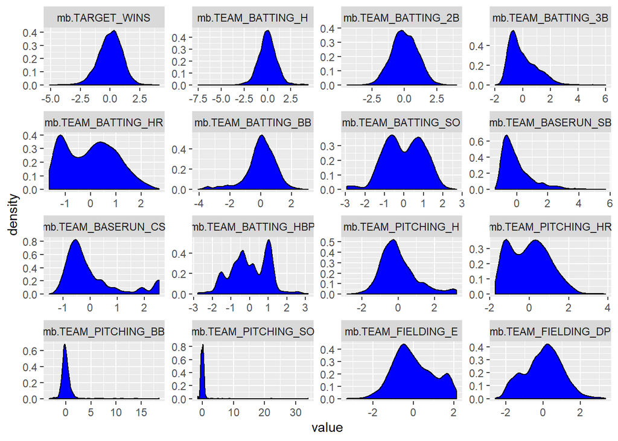

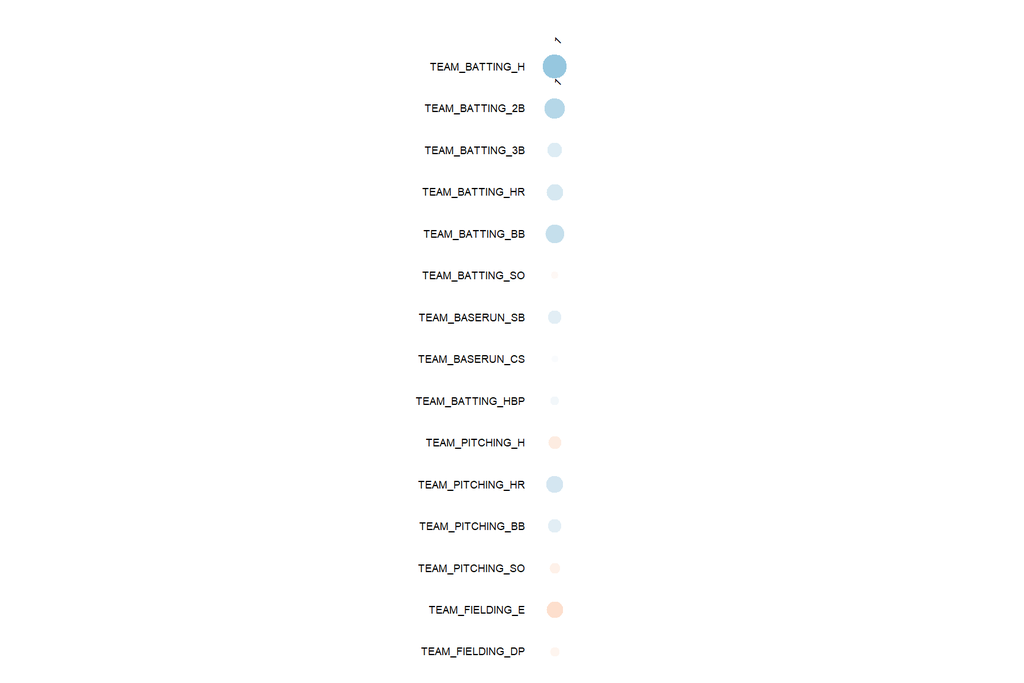

We have more postive correlation with the target variable than the previous correlation plot.

## Part iii. BUILD MODELS

### Model 1

For the first model approach, we decide to create a regression on the raw data using all the variables on the data set. As we can observe we have many variables that don’t have a good significance level. In our first model attempt, we obtain an R Squared value of 0.5501 and an adjusted R-square value of 0.5116, noticing that the difference maybe because of the numbers of variables in the regression that doesn’t have a significance level. Also, we obtain a low F-statistic result.

```
##
## Call:
## lm(formula = TARGET_WINS ~ ., data = moneyball_training_data[,
##     -1])
##
## Residuals:
##      Min       1Q   Median       3Q      Max
## -19.8708  -5.6564  -0.0599   5.2545  22.9274
##
## Coefficients:
##                  Estimate Std. Error t value Pr(>|t|)
## (Intercept)      60.28826   19.67842   3.064  0.00253 **
## TEAM_BATTING_H    1.91348    2.76139   0.693  0.48927
## TEAM_BATTING_2B   0.02639    0.03029   0.871  0.38484
## TEAM_BATTING_3B  -0.10118    0.07751  -1.305  0.19348
## TEAM_BATTING_HR  -4.84371   10.50851  -0.461  0.64542
## TEAM_BATTING_BB  -4.45969    3.63624  -1.226  0.22167
## TEAM_BATTING_SO   0.34196    2.59876   0.132  0.89546
## TEAM_BASERUN_SB   0.03304    0.02867   1.152  0.25071
## TEAM_BASERUN_CS  -0.01104    0.07143  -0.155  0.87730
## TEAM_BATTING_HBP  0.08247    0.04960   1.663  0.09815 .
## TEAM_PITCHING_H  -1.89096    2.76095  -0.685  0.49432
## TEAM_PITCHING_HR  4.93043   10.50664   0.469  0.63946
## TEAM_PITCHING_BB  4.51089    3.63372   1.241  0.21612
## TEAM_PITCHING_SO -0.37364    2.59705  -0.144  0.88577
## TEAM_FIELDING_E  -0.17204    0.04140  -4.155 5.08e-05 ***
## TEAM_FIELDING_DP -0.10819    0.03654  -2.961  0.00349 **
## ---
## Signif. codes:  0 '***' 0.001 '**' 0.01 '*' 0.05 '.' 0.1 ' ' 1
##
## Residual standard error: 8.467 on 175 degrees of freedom
##   (2085 observations deleted due to missingness)
## Multiple R-squared:  0.5501, Adjusted R-squared:  0.5116
## F-statistic: 14.27 on 15 and 175 DF,  p-value: < 2.2e-16
```

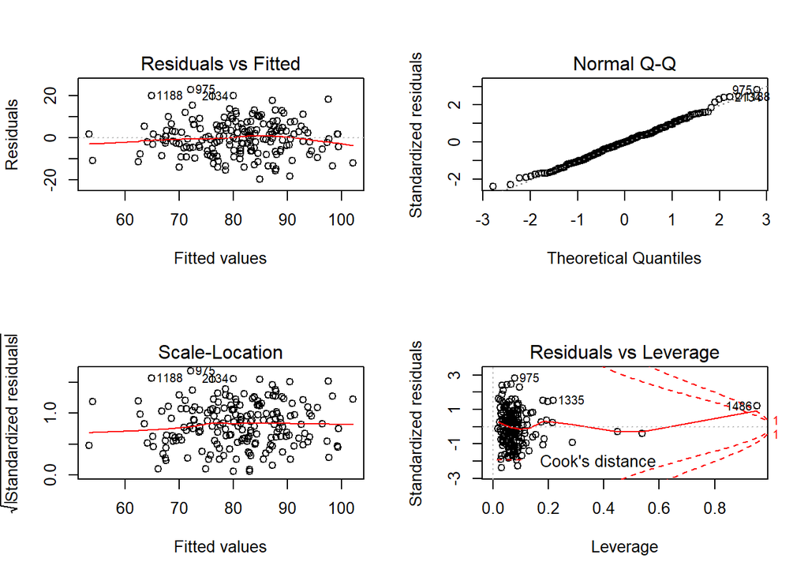

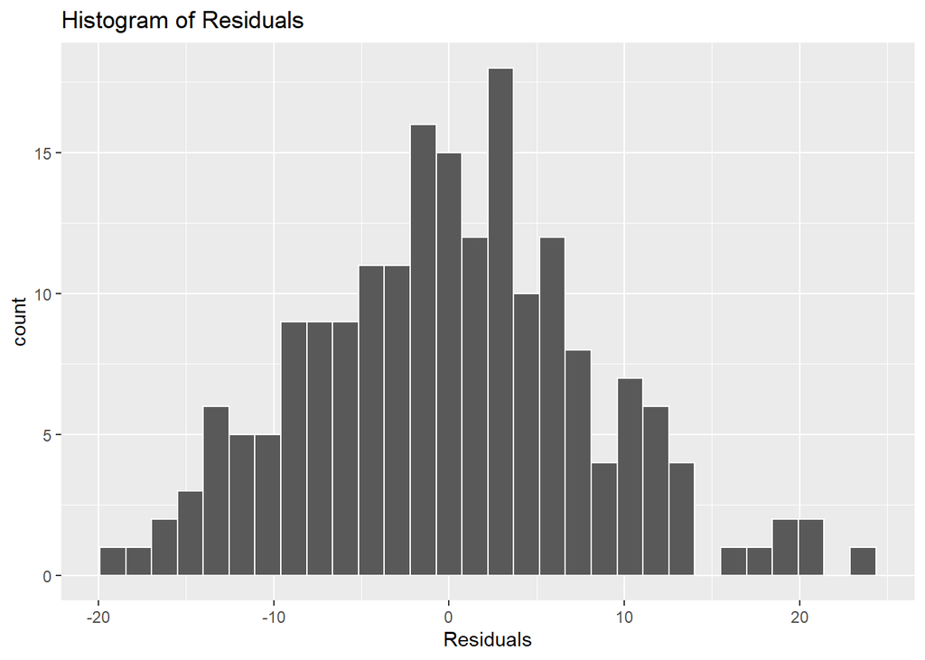

On a whole, the model is significant. However `2085` observations were removed due to missingness which makes the model skeptical. The residual plot seems normal with the points distributed randomly. We should be somewhat concerned with the outliers in the qq-plot which caused the tails of the plot to turn into the opposite direction. The variation in the third plot (bottom-left) seems to display homoscedasticity.

### Model 2

```
##
## Call:
## lm(formula = TARGET_WINS ~ TEAM_BATTING_H + TEAM_BATTING_2B +
##     TEAM_BATTING_3B + TEAM_BATTING_HR + TEAM_BATTING_BB + TEAM_BATTING_SO +
##     TEAM_BASERUN_SB + TEAM_BASERUN_CS + TEAM_PITCHING_H + TEAM_PITCHING_HR +
##     TEAM_PITCHING_BB + TEAM_PITCHING_SO + TEAM_FIELDING_E + TEAM_FIELDING_DP,
##     data = meta_filter)
##
## Residuals:
##      Min       1Q   Median       3Q      Max
## -23.8165  -6.6792   0.1261   6.2821  22.8485
##
## Coefficients:
##                    Estimate Std. Error t value Pr(>|t|)
## (Intercept)      31.5992851 13.9216579   2.270  0.02368 *
## TEAM_BATTING_H    0.0514584  0.0377933   1.362  0.17400
## TEAM_BATTING_2B  -0.0565008  0.0185335  -3.049  0.00243 **
## TEAM_BATTING_3B   0.1392117  0.0423792   3.285  0.00110 **
## TEAM_BATTING_HR  -0.0282346  0.2850461  -0.099  0.92114
## TEAM_BATTING_BB  -0.1062370  0.0956209  -1.111  0.26714
## TEAM_BATTING_SO   0.0913935  0.0467464   1.955  0.05118 .
## TEAM_BASERUN_SB   0.0312539  0.0164747   1.897  0.05844 .
## TEAM_BASERUN_CS  -0.0312946  0.0395656  -0.791  0.42938
## TEAM_PITCHING_H  -0.0008172  0.0357390  -0.023  0.98177
## TEAM_PITCHING_HR  0.0952730  0.2736531   0.348  0.72788
## TEAM_PITCHING_BB  0.1375139  0.0929499   1.479  0.13971
## TEAM_PITCHING_SO -0.0953209  0.0444738  -2.143  0.03261 *
## TEAM_FIELDING_E  -0.1623533  0.0297495  -5.457 7.91e-08 ***
## TEAM_FIELDING_DP -0.1016161  0.0247806  -4.101 4.87e-05 ***
## ---
## Signif. codes:  0 '***' 0.001 '**' 0.01 '*' 0.05 '.' 0.1 ' ' 1
##
## Residual standard error: 9.688 on 461 degrees of freedom
##   (33 observations deleted due to missingness)
## Multiple R-squared:  0.3219, Adjusted R-squared:  0.3014
## F-statistic: 15.63 on 14 and 461 DF,  p-value: < 2.2e-16
```

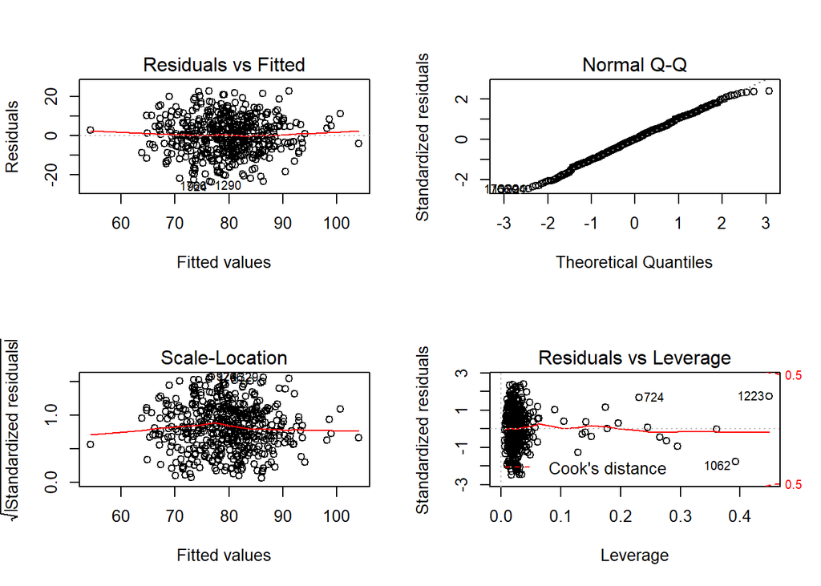

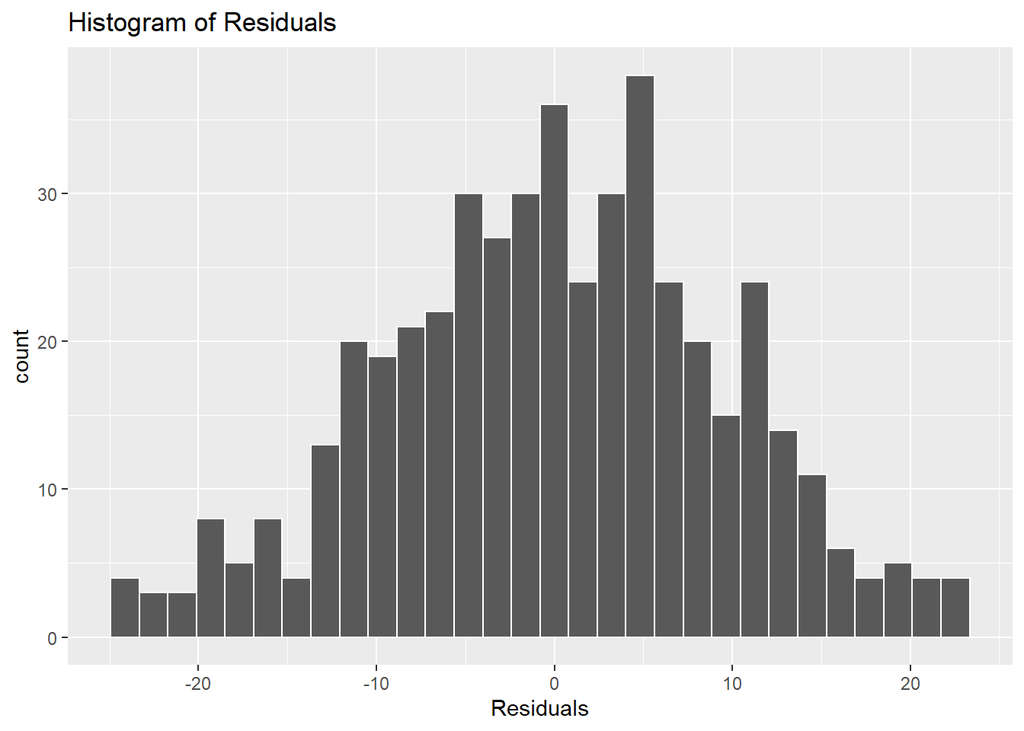

### Model 3

We observed that we have a lot missing data in our raw dataset and to solve this and hope to see an improvement in our model we decide to work by doing multiple imputations in our training data and after that create a new model.

```
##
## Call:
## lm(formula = TARGET_WINS ~ ., data = imputed_train_data)
##
## Residuals:
##     Min      1Q  Median      3Q     Max
## -50.308  -8.429   0.262   8.022  46.776
##
## Coefficients:
##                    Estimate Std. Error t value Pr(>|t|)
## (Intercept)      32.4215968  5.3247937   6.089 1.33e-09 ***
## TEAM_BATTING_H    0.0429219  0.0035525  12.082  < 2e-16 ***
## TEAM_BATTING_2B  -0.0217313  0.0088293  -2.461 0.013918 *
## TEAM_BATTING_3B   0.0313910  0.0163183   1.924 0.054522 .
## TEAM_BATTING_HR   0.0606282  0.0263058   2.305 0.021271 *
## TEAM_BATTING_BB   0.0193784  0.0056640   3.421 0.000634 ***
## TEAM_BATTING_SO  -0.0163874  0.0024659  -6.646 3.77e-11 ***
## TEAM_BASERUN_SB   0.0599810  0.0052927  11.333  < 2e-16 ***
## TEAM_BASERUN_CS  -0.0184157  0.0105683  -1.743 0.081548 .
## TEAM_BATTING_HBP  0.0632476  0.0252139   2.508 0.012196 *
## TEAM_PITCHING_H   0.0014835  0.0003808   3.896 0.000101 ***
## TEAM_PITCHING_HR  0.0168792  0.0234027   0.721 0.470829
## TEAM_PITCHING_BB -0.0088860  0.0040068  -2.218 0.026673 *
## TEAM_PITCHING_SO  0.0031946  0.0008956   3.567 0.000369 ***
## TEAM_FIELDING_E  -0.0421098  0.0026422 -15.937  < 2e-16 ***
## TEAM_FIELDING_DP -0.1221000  0.0126844  -9.626  < 2e-16 ***
## ---
## Signif. codes:  0 '***' 0.001 '**' 0.01 '*' 0.05 '.' 0.1 ' ' 1
##
## Residual standard error: 12.53 on 2260 degrees of freedom
## Multiple R-squared:  0.3716, Adjusted R-squared:  0.3674
## F-statistic:  89.1 on 15 and 2260 DF,  p-value: < 2.2e-16
```

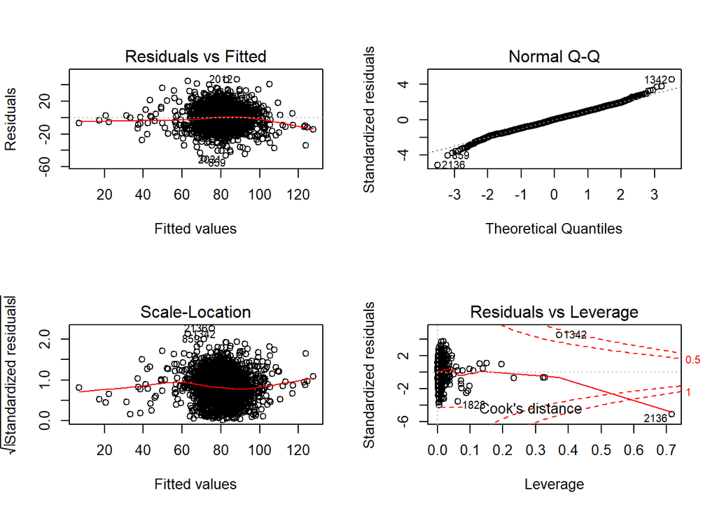

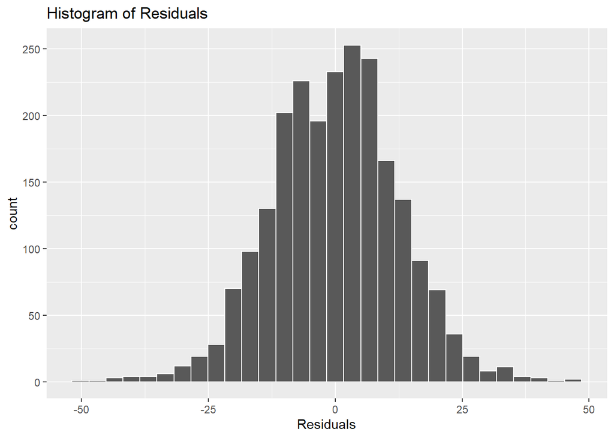

In this model, we definitely obtained more statistical significance variables and a good increase on f-statistics. This is an improvement compared to model 2 because the missing values were imputed. This gave the model more options to work with.

### Model 4

This model is built on removing multicollinearity from the model 3 for improved results. The rule of thumb is to remove any variables with a score of more than 5.

```
##   TEAM_BATTING_H  TEAM_BATTING_2B  TEAM_BATTING_3B  TEAM_BATTING_HR
##         3.824178         2.474938         3.012718        36.769145
##  TEAM_BATTING_BB  TEAM_BATTING_SO  TEAM_BASERUN_SB  TEAM_BASERUN_CS
##         6.997200         5.365888         3.931167         3.922233
## TEAM_BATTING_HBP  TEAM_PITCHING_H TEAM_PITCHING_HR TEAM_PITCHING_BB
##         1.140037         4.160152        29.828536         6.440010
## TEAM_PITCHING_SO  TEAM_FIELDING_E TEAM_FIELDING_DP
##         3.426995         5.249712         2.051073
```

TEAM_BATTING_HR has a high VIF (highly correlated) score so it will be the first to be removed from the model.

```
##   TEAM_BATTING_H  TEAM_BATTING_2B  TEAM_BATTING_3B  TEAM_BATTING_BB
##         3.812960         2.474181         2.884116         5.615529
##  TEAM_BATTING_SO  TEAM_BASERUN_SB  TEAM_BASERUN_CS TEAM_BATTING_HBP
##         5.340989         3.928034         3.921867         1.136316
##  TEAM_PITCHING_H TEAM_PITCHING_HR TEAM_PITCHING_BB TEAM_PITCHING_SO
##         4.138367         3.802642         5.000993         3.175985
##  TEAM_FIELDING_E TEAM_FIELDING_DP
##         5.244291         2.051018
```

Next we remove TEAM_BATTING_BB

```
##   TEAM_BATTING_H  TEAM_BATTING_2B  TEAM_BATTING_3B  TEAM_BATTING_SO
##         3.811750         2.469475         2.882555         5.135989
##  TEAM_BASERUN_SB  TEAM_BASERUN_CS TEAM_BATTING_HBP  TEAM_PITCHING_H
##         3.927827         3.921833         1.112140         3.437098
## TEAM_PITCHING_HR TEAM_PITCHING_BB TEAM_PITCHING_SO  TEAM_FIELDING_E
##         3.802252         1.846735         2.306046         4.978480
## TEAM_FIELDING_DP
##         1.980628
```

TEAM_BATTING_SO

```
##   TEAM_BATTING_H  TEAM_BATTING_2B  TEAM_BATTING_3B  TEAM_BASERUN_SB
##         3.157901         2.359989         2.815128         3.720868
##  TEAM_BASERUN_CS TEAM_BATTING_HBP  TEAM_PITCHING_H TEAM_PITCHING_HR
##         3.908211         1.107066         3.400599         2.441104
## TEAM_PITCHING_BB TEAM_PITCHING_SO  TEAM_FIELDING_E TEAM_FIELDING_DP
##         1.689236         1.872926         4.791321         1.966047
```

Multicollinearity is no longer present in this model. We can establish that `TEAM_BATTING_BB, TEAM_BATTING_SO and TEAM_BATTING_HR` are all dependent on other predictor variables and so they were removed from the model.

```
##
## Call:
## lm(formula = TARGET_WINS ~ TEAM_BATTING_H + TEAM_BATTING_2B +
##     TEAM_BATTING_3B + TEAM_BASERUN_SB + TEAM_BASERUN_CS + TEAM_BATTING_HBP +
##     TEAM_PITCHING_H + TEAM_PITCHING_HR + TEAM_PITCHING_BB + TEAM_PITCHING_SO +
##     TEAM_FIELDING_E + TEAM_FIELDING_DP, data = imputed_train_data)
##
## Residuals:
##     Min      1Q  Median      3Q     Max
## -52.212  -8.669   0.270   8.274  45.415
##
## Coefficients:
##                    Estimate Std. Error t value Pr(>|t|)
## (Intercept)      17.8086199  3.9013570   4.565 5.27e-06 ***
## TEAM_BATTING_H    0.0519650  0.0032698  15.892  < 2e-16 ***
## TEAM_BATTING_2B  -0.0299403  0.0087330  -3.428 0.000618 ***
## TEAM_BATTING_3B   0.0355485  0.0159776   2.225 0.026187 *
## TEAM_BASERUN_SB   0.0529770  0.0052156  10.157  < 2e-16 ***
## TEAM_BASERUN_CS  -0.0152922  0.0106854  -1.431 0.152531
## TEAM_BATTING_HBP  0.0511955  0.0251671   2.034 0.042046 *
## TEAM_PITCHING_H   0.0009723  0.0003487   2.788 0.005345 **
## TEAM_PITCHING_HR  0.0394807  0.0067812   5.822 6.64e-09 ***
## TEAM_PITCHING_BB  0.0041987  0.0020786   2.020 0.043504 *
## TEAM_PITCHING_SO -0.0002819  0.0006706  -0.420 0.674231
## TEAM_FIELDING_E  -0.0424416  0.0025568 -16.600  < 2e-16 ***
## TEAM_FIELDING_DP -0.1042555  0.0125789  -8.288  < 2e-16 ***
## ---
## Signif. codes:  0 '***' 0.001 '**' 0.01 '*' 0.05 '.' 0.1 ' ' 1
##
## Residual standard error: 12.69 on 2263 degrees of freedom
## Multiple R-squared:  0.3544, Adjusted R-squared:  0.351
## F-statistic: 103.5 on 12 and 2263 DF,  p-value: < 2.2e-16
```

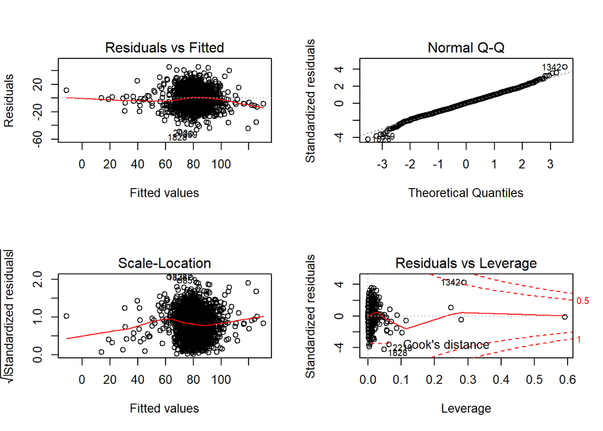

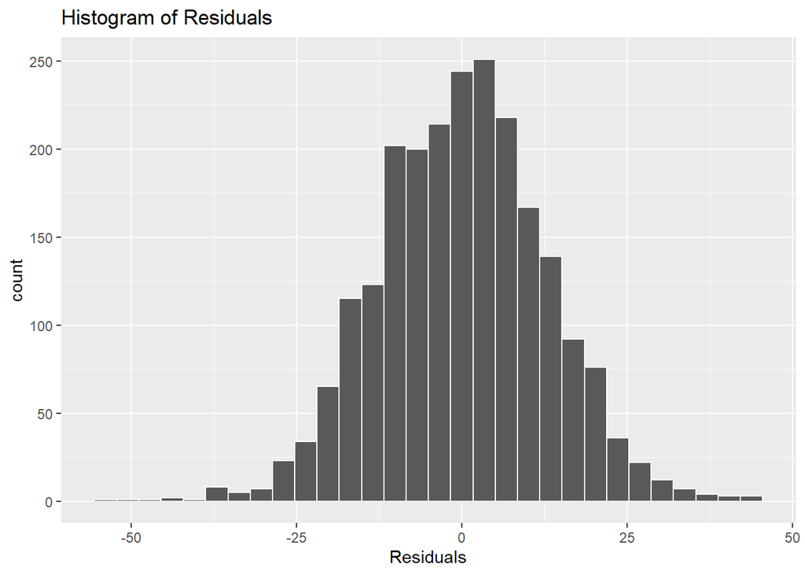

Even with multicollinearity removed, the Adj R-Squared did not increase. There is curvature in the scale-location plot which indicates non-contant variance.